# Global_analysis

Jure Fabjan

2022-11-03

# Prepare parameters

```r
set.seed(123)
```

# Global parameters

```r
fold_cutoff = 1
```

# Reading data

```r
data <- read.csv(str_c(params$path0, "rnaseq_deseq_global_counts_raw.tsv"), sep="\t")
samples <- read.csv(str_c(params$path0,"rnaseq_deseq_global_samples.tsv"), sep="\t")
contrasts <- read.csv(str_c(params$path0,"rnaseq_deseq_global_contrasts_summary.tsv"), sep="\t")
gene_an <- read.csv(str_c(params$path0,"rnaseq_deseq_global_annotation_gene.tsv"), sep="\t")
```

# Formatting the metadata

We add the processing dates to the samples. We define batches based on the dates.

```r
samples$isolation <- ""
samples$isolation[samples$individual %in% c("K78_17", "K9_18")] <- "19.12.2017"
samples$isolation[samples$individual %in% c("K1_18", "K2_18")] <- "05.02.2018"
samples$isolation[samples$individual %in% c("K11_18", "K12_18")] <- "27.02.2018"
samples$isolation[samples$individual %in% c("K18_18", "K19_18")] <- "24.04.2018"
samples$isolation[samples$individual %in% c("K20_18", "K21_18")] <- "25.04.2018"
samples$isolation[samples$individual %in% c("K23_18", "K24_18")] <- "06.06.2018"
samples$isolation[samples$individual %in% c("K34_18", "K36_18")] <- "03.12.2018"
samples$isolation[samples$individual %in% c("K5_18")] <- "12.02.2018"
samples$isolation[samples$individual %in% c("K57_15")] <- "16.06.2015"
samples$isolation[samples$individual %in% c("K37_18")] <- "04.12.2018"
samples$isolation[samples$individual %in% c("K35_18")] <- "11.12.2018"

samples$batch <- match(samples$isolation, unique(samples$isolation))
```

Some samples are not paired - don’t have a counterpart with a different experimental conditions. Thus, we label these samples.

```r
samples$paired <- TRUE
samples$paired[samples$individual %in% c("K5_18", "K57_15", "K37_18", "K35_18")] <- FALSE
```

Next we remove the extra metadata columns from the data table. Before doing so we store gene IDs as row names.

```r
data = data %>% column_to_rownames(var="gene_id")
subdata <- data[, !(names(data) %in% c("gene_version", "gene_name", "gene_biotype", "gene_source", "location"))]
```

We also mine Ensembl for gene descriptors we will need later.

```r
genes = data.frame(gene_ids = gene_an$gene_id)

ensembl = useMart("ENSEMBL_MART_ENSEMBL")
ensembl = useDataset("hsapiens_gene_ensembl", mart=ensembl)
geneannot = getBM(attributes = c("ensembl_gene_id", "description", "entrezgene_id"),
                  filters="ensembl_gene_id",
                  values=genes, mart=ensembl)
geneannot = geneannot[!duplicated(geneannot$ensembl_gene_id),]
genes = genes %>% left_join(geneannot, by=c("gene_ids"="ensembl_gene_id"))
gene_an = gene_an %>% left_join(genes, by=c("gene_id"="gene_ids"))
rownames(gene_an) = gene_an$gene_id
```

```r
gene_an[c("ENSG00000183889", "ENSG00000233024"), "entrezgene_id"] = 105376752
gene_an["ENSG00000170667", "entrezgene_id"] = 100271927
gene_an[c("ENSG00000285269", "ENSG00000226266", "ENSG00000257524"), "entrezgene_id"] = NA
gene_an["ENSG00000179304", "entrezgene_id"] = 727866
gene_an["ENSG00000237541", "entrezgene_id"] = 3118
gene_an["ENSG00000228696", "entrezgene_id"] = 100506084
gene_an["ENSG00000278662", "entrezgene_id"] = 647042
gene_an["ENSG00000278970", "entrezgene_id"] = 100859930
gene_an["ENSG00000205571", "entrezgene_id"] = 6607
gene_an["ENSG00000132207", "entrezgene_id"] = 548593
gene_an["ENSG00000205572", "entrezgene_id"] = 728492
```

# Data filtering

We filter out the low count genes. We adapt also the gene annotation.

```r
data_filtered <- subdata[rowSums(subdata > 10) > 5,]
gene_filtered_an <- gene_an[gene_an$gene_id %in% rownames(data_filtered),]
```

Next we remove the outliers. We use the subsetting function.

```r
subsamples <- samples[samples$individual != "K36_18",]
data_filtered <- data_filtered[,names(data_filtered) %in% subsamples$sample]
rownames(subsamples) <- subsamples$sample

rownames(gene_filtered_an) <- gene_filtered_an$gene_id

experiment <- SummarizedExperiment(assays = list(counts=as.matrix(data_filtered)),
                                   colData = subsamples,
                                   rowData = gene_filtered_an)
```

# DESeqDataSeq creation and testing

```r
dds <- DESeqDataSet(experiment, design = ~ group + isolation)
dds <- DESeq(dds, test="LRT", reduced = ~ isolation)
```

# Dispersion estimeation

We need to estimate the dispersion trend and transform the data for later plotting.

```r
vst_data <- vst(dds, blind = FALSE)
```

# Comparisons

## Genotype: control cells vs X-ALD cells without myelin exposure

### Extraction of results

```r
res_genotype <- results(dds, alpha=0.01, contrast=c("group", "ALD_wo_myelin", "WT_wo_myelin"))
```

### Analysis of results

We save the results.

```r
if (!dir.exists(str_c(params$outfolder, "Genotype/"))) {
  dir.create(str_c(params$outfolder, "Genotype/"), recursive=TRUE)
}
results_temp = res_genotype
results_temp$gene_name = gene_an$gene_name[match(row.names(results_temp), gene_an$gene_id)]
results_temp$gene_biotype <- gene_an$gene_biotype[match(row.names(results_temp), gene_an$gene_id)]
results_temp$location <- gene_an$location[match(row.names(results_temp), gene_an$gene_id)]

write.csv(results_temp, file=str_c(params$outfolder, "Genotype/", "Results.csv"))
remove(results_temp)
```

### Protein-protein interraction network

We use cytoscape for plotting, so the program needs to run before this code block is executed. First we prepare the data.

```r
res_genotype_clean <- res_genotype[!is.na(res_genotype$log2FoldChange) & !is.na(res_genotype$padj),]
res_genotype_clean <- res_genotype_clean[(res_genotype_clean$padj < 0.01) & (abs(res_genotype_clean$log2FoldChange) > fold_cutoff),]
res_genotype_clean$gene <- gene_an$gene_name[match(row.names(res_genotype_clean), gene_an$gene_id)]
res_genotype_clean$gene_id <- row.names(res_genotype_clean)
```

Next we push the data to cytoscape. We use logFC values for coloring of the nodes. In the end we save the session into the output folder.

```r
cytoscapePing()
```

```
## You are connected to Cytoscape!
```

```r
string.cmd = paste('string protein query query="', paste(res_genotype_clean$gene_id, collapse=',') , '" cutoff=0.9 species="Homo sapiens"', sep="")
commandsRun(string.cmd)
```

```
## [1] "Loaded network 'STRING network' with 137 nodes and 103 edges"
```

```r
layoutNetwork("attribute-circle")
deleteStyleMapping(style.name = "STRING style v1.5", visual.prop = "NODE_CUSTOMGRAPHICS_1")

column <- "query term"
values <- getTableColumns("node", column)
values <- values[!is.na(values)]
values <- data.frame(values=values, logFC=res_genotype_clean$log2FoldChange[match(values, res_genotype_clean$gene_id)])
values$logFC <- res_genotype_clean$log2FoldChange[match(values$values, res_genotype_clean$gene_id)]

pal <- scale_color_gradient2_tableau("Classic Red-Green", trans = "reverse")
values$colors <- pal$palette((values$logFC-min(values$logFC))/(max(values$logFC)-min(values$logFC)))
setNodeColorDefault('#CCCCCC', style.name = "STRING style v1.5")
setNodeColorMapping(column, values$values, values$colors, mapping.type="d", style.name="STRING style v1.5")
```

```r
saveSession(str_c(params$outfolder, "Genotype/","Prot-prot_network.cys"))
```

### GO analysis

Preparing the gene lists and testing GO.

```r
genes = rowData(dds)[rownames(res_genotype)[res_genotype$padj<0.05 & !is.na(res_genotype$padj)],]$entrezgene_id
genes = genes[!is.na(genes)]

genotype_GO = goana(genes, species="Hs")
genotype_GO$P.DE_adjust = p.adjust(genotype_GO$P.DE, method="BH")
```

Saving the results.

```r
write.csv(genotype_GO, str_c(params$outfolder, "Genotype/", "GO_enrichment.csv"))
```

Plotting of GO results.

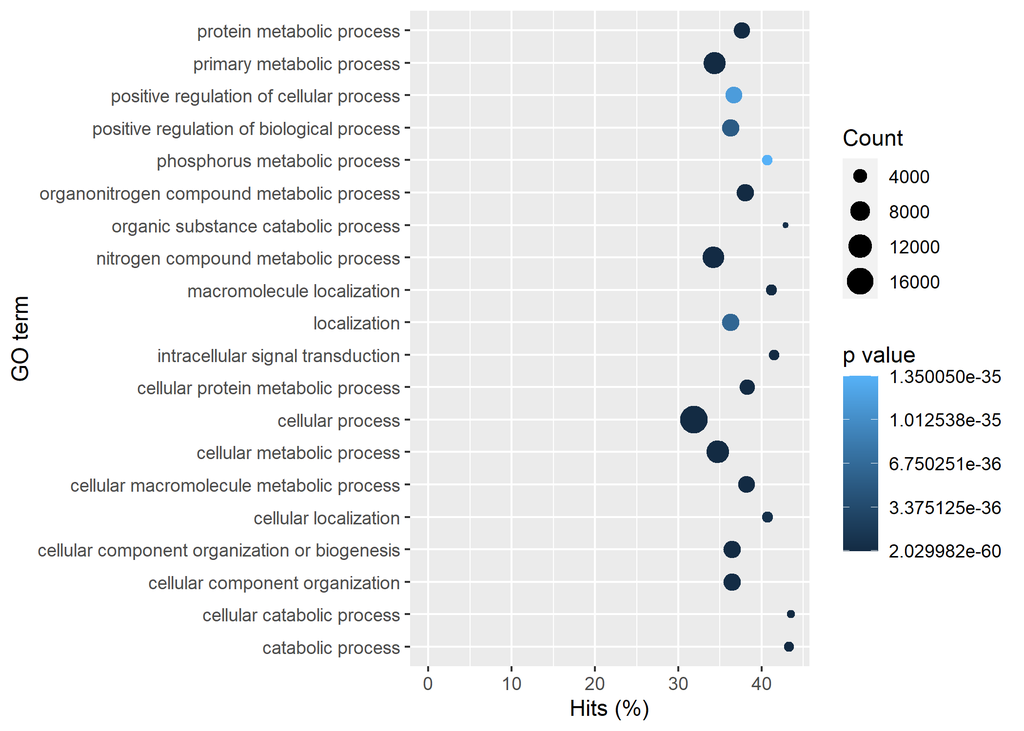

### KEGG

```r
genotype_KEGG = kegga(genes, species="Hs")
genotype_KEGG$P.DE_adjust = p.adjust(genotype_KEGG$P.DE, method="BH")

write.csv(genotype_KEGG, str_c(params$outfolder, "Genotype/", "KEGG_enrichment.csv"))
```

### Looking at genes of interest

```r
interesting_genes <- c("LAMP3",
                       "LAMP5",
                       "IL36B",
                       "IL36RN",
                       "LEP",
                       "CCL13",
                       "CXCL12",
                       "CDH1",
                       "NOS3",
                       "CLU",
                       "IL2RA")
```

We subset the data of interest.

```r
interesting_data <- assay(vst_data)[gene_filtered_an$gene_id[gene_filtered_an$gene_name %in% interesting_genes], dds$sample[dds$group %in% c("WT_wo_myelin", "ALD_wo_myelin")]]
rownames(interesting_data) <- gene_filtered_an$gene_name[match(rownames(interesting_data), gene_filtered_an$gene_id)]
interesting_data <- melt(interesting_data)
colnames(interesting_data) <- c("gene_name", "sample", "value")
interesting_data$group <- dds$group[match(interesting_data$sample, dds$sample)]
```

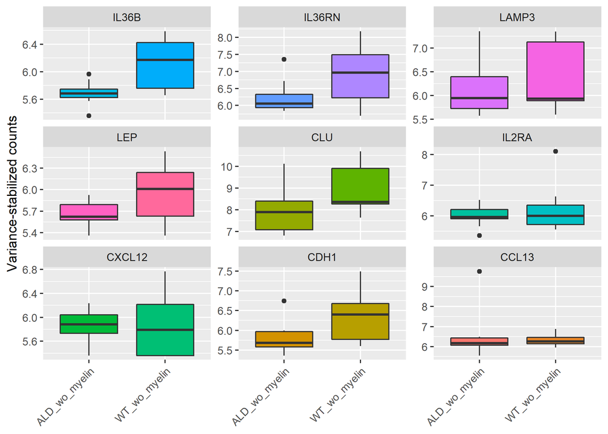

### Reactome pathways

```r
x <- enrichPathway(gene=names(entrez), pvalueCutoff = 0.05, readable=T)
```

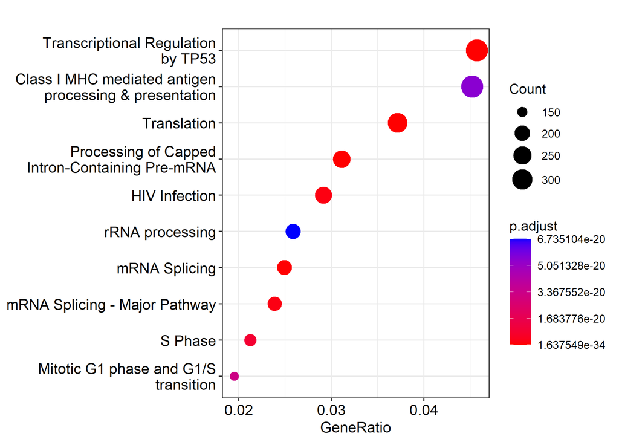

### DNA pathways

We first normalize data to TPM and then log2 transform.

```r
data_subset <- subdata[,samples$sample[samples$group %in% c("WT_wo_myelin", "ALD_wo_myelin")]]

hub <- AnnotationHub()
```

```
## snapshotDate(): 2022-04-25
```

```r
ensdb <- hub[["AH95744"]]
```

```
## loading from cache
```

```
## require("ensembldb")
```

```r
txsByGene <- transcriptsBy(ensdb, by="gene")
lengthData <- median(width(txsByGene)) / 1000
lengthData <- lengthData[match(rownames(data_subset), names(lengthData))]
data_subset <- data_subset / lengthData
data_subset <- t( t(data_subset) * 1e6 / colSums(data_subset, na.rm=TRUE))

data_subset <- log2(data_subset+1)
```

```r
data_subset <- data_subset[rowSums(data_subset > 0) > (length(colnames(data_subset))/3),]
```

We replace row names with entrez gene IDs and remove entries without it. We also prepare group data for each sample.

```r
# Transform symbols to entrez and remove the ones that don't have it
rownames(data_subset) = rowData(dds)[rownames(data_subset),]$entrezgene_id
data_subset <- data_subset[!is.na(rownames(data_subset)),]
```

```r
data_subset_02 <- t(data_subset[rownames(data_subset) != "NULL",])

data_subset_02 = data_subset_02[,!(duplicated(colnames(data_subset_02)))]

data_groups = samples[samples$sample %in% rownames(data_subset_02), c("sample", "group")]
data_groups$group = as.numeric(as.factor(data_groups$group))-1
temp_samples = data_groups$sample
data_groups = data_groups$group
names(data_groups) = temp_samples
```

Next we perform the testing.

[output not shown]

Finally, we save graphs of individual paths in PDF files.

```r
subresults <- filter_pathways(results, alpha_pathway=0.01)
subresults_sym <- rename_genes(subresults, to = "symbol", species = "human")
```

```
## Connecting to biomaRt database...
```

```
##  - saving gene info to C:\Users\Jure\AppData\Local\Temp\RtmpWaiTMs/entrez_to_hsapiens.rds
```

```r
for (i in 1:length(subresults_sym)) {
  pdf(str_c(params$outfolder, gsub(" ", "_", names(subresults_sym[[i]]), fixed=TRUE), ".pdf"))
  plot(subresults_sym[[i]])
  dev.off()
}
```

# Session info

```r
print(date())
```

```
## [1] "Thu Nov  3 10:20:35 2022"
```

```r
print(tictoc::toc())
```

```
## 2149.72 sec elapsed
## $tic
## elapsed
##    0.92
##
## $toc
## elapsed
## 2150.64
##
## $msg
## logical(0)
##
## $callback_msg
## [1] "2149.72 sec elapsed"
```